# The association of Google suicide search and suicides in Greece

## Introduction

Increase in suicides after the economic crisis in Greece (Rachiotis, Stuckler, McKee, & Hadjichristodoulou, 2015)

Easy access to information about suicide methods and pro-suicide web sites on the Internet appears to contribute to a small but significant proportion of suicides (Gunnell et al., 2012)

Significant associations between suicide death and a set of suicide-related search terms (Yang, Tsai, Huang, & Peng, 2011)

In US states with higher suicide rates, there were more searches of terms associated with suicide (Gunn III & Lester, 2013)

Hypothesis: Google search for suicide correlates positevely with the actual number of suicides

## Method

Online search

Data

Google trends: Google searches for “suicide”

general web, 2010-2016, Greece

HELSTAT: Actual number of suicide deaths per year, 2010-2016

## Method

Analysis in R

Import data

Keep only years and hits from Google trends

Mean of Gooogle searches per year

Pearson correlation

## Results

The correlation between the mean of Google searches for suicide and actual suicides was:

*r* = -0.15, *p* = 0.75

There is not a significant correlation.

The hypothesis was not supported.

## Plot

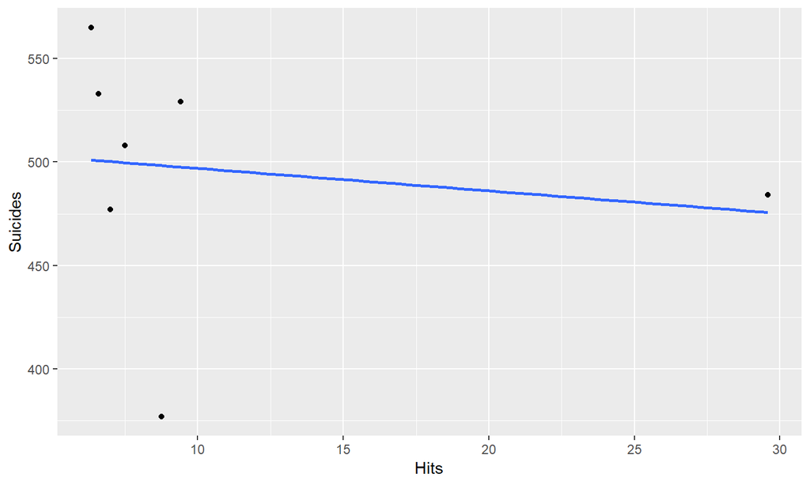

## Discussion

Problems with importing data from Google trends

Searching for suicide not only with the purpose of suicide attempt

People do not want to arouse any suspicions about their thoughts for commiting suicide, so they do not search in the Internet

In Greece, most of the people do not search for suicide in the Interent before the commit.

## References

Gunnell, D., Bennewith, O., Kapur, N., Simkin, S., Cooper, J., & Hawton, K. (2012). The use of the internet by people who die by suicide in england: A cross sectional study. *Journal of Affective Disorders*, *141*(2), 480–483. https://doi.org/10.1016/j.jad.2012.04.015

Gunn III, J. F., & Lester, D. (2013). Using google searches on the internet to monitor suicidal behavior. *Journal of Affective Disorders*, *148*(2), 411–412. https://doi.org/10.1016/j.jad.2012.11.004

Rachiotis, G., Stuckler, D., McKee, M., & Hadjichristodoulou, C. (2015). What has happened to suicides during the greek economic crisis? Findings from an ecological study of suicides and their determinants (2003-2012). *BMJ Open*, *5*(3), e007295–e007295. https://doi.org/10.1136/bmjopen-2014-007295

Yang, A. C., Tsai, S.-J., Huang, N. E., & Peng, C.-K. (2011). Association of internet search trends with suicide death in taipei city, taiwan, 2004–2009. *Journal of Affective Disorders*, *132*(1), 179–184. https://doi.org/10.1016/j.jad.2011.01.019